# Análise Multivariada

Prática: Análise Discriminante (`hemofilia.DAT`)

### Objetivo

Ajustar e medir desempenho de modelos de discriminação linear e quadrático. Apresentação e uso de métodos de reamoostragem como técnicas de avaliação e validação do modelo preditivo.

### Dados e contexto

Na investigação de mulheres portadoras do gene defeituoso (geralmente ligado ao cromossomo X), as medidas `log10(AHF anticorpo)` e `log10(AHF antígeno)` são usadas para avaliar a relação entre a atividade do fator de coagulação (AHF - antihemophilic factor). Dessa maneira definem-se:

- `AHF` (Fator VIII) – Atividade (Anticorpo): avalia quanto o fator de coagulação está funcional no plasma. Sua transformação logarítmica (base 10) é usada para normalizar a distribuição dos dados e facilitar comparações.
- AHF (Fator VIII) – Antígeno: medido por ensaios imunológicos (ex.: ELISA), quantifica a proteína do fator de coagulação presente, independentemente de sua função. A transformação logarítmica da concentração do antígeno tem as mesmas finalidades da medida anterior.

As mulheres portadoras do gene da hemofilia (heterozigotas) geralmente têm:

- Atividade do Fator VIII (AHF anticorpo) reduzida (devido à inativação aleatória de X, pela Lyonização).
- Níveis de antígeno (AHF antígeno) normais ou levemente reduzidos (pois produzem parte da proteína, mesmo que disfuncional).

Em portadoras, a atividade (AHF anticorpo) é desproporcionalmente menor que o antígeno, pois parte do fator coagulante é defeituoso. Mulheres não portadoras têm proporção próxima de 1:1. A transformação logarítmica melhora a visualização de diferenças sutis, especialmente em casos limítrofes. Seja um exemplo prático, em que uma mulher tem: AHF anticorpo = 40% (log10 = ~1,60) e AHF antígeno = 80% (log10 = ~1,90). A diferença logarítmica (0,3) sugere desequilíbrio, indicando que ela pode ser portadora.

Há limitações com o método, pois os resultados podem variar devido à Lyonização aleatória. O teste genético (identificação da mutação no gene FVIII) ainda é o padrão-ouro para confirmação. De qualquer maneira, a comparação entre log10(AHF anticorpo) e log10(AHF antígeno) é uma ferramenta útil para **triagem** de portadoras, destacando discrepâncias entre função e quantidade do Fator VIII. Porém, para diagnóstico definitivo, deve ser complementada com análise genética.

O conjunto de dados está disponível no arquivo `hemofilia.DAT`, sendo utilizado nos Exemplo 11.3 e 11.4, em JOHNSON; WICHERN (2007, p. 590). Ele é composto por 75 observações de 3 variáveis, descritas a seguir:

| Itens | Descrição | Valores | Tipo |
| --- | --- | --- | --- |
| `X1` | Grupo de mulheres | `1`: mulheres não portadoras e `2`: mulheres portadoras | factor |
| `X2` | Medidas de log10(atividade AHF) | logarítmo da concentração de AHF anticorpo | numeric |
| `X3` | Medidas de log10(atividade antígeno) | logarítmo da concentração de AHF antígeno | numeric |

```r
hemofilia <- read.table("../dados/T11-8.DAT")
hemofilia[, 1] <- as.factor(hemofilia[, 1])
names(hemofilia) <- c("grupo", "anticorpo","antigeno")

  # Tamanho de cada grupo
tabela <- table(hemofilia$grupo)
n1 <- tabela[[1]]
n2 <- tabela[[2]]
```

O primeiro dos grupos é composto por $n_1 = 30$ mulheres que não são portadoras do gene da hemofilia A, o outro grupo contém $n_2 = 45$ mulheres portadoras conhecidas de hemofilia A (filhas de hemofílicos, mães com mais de um filho hemofílico, mães com um filho hemofílico e outros parentes hemofílicos). Esse grupo foi chamado de portadores obrigatórios (*obligatory carriers*).

Os vetores de médias amostrais dos dois grupos, $\bar{\mathbf{x}}_1$ e $\bar{\mathbf{x}}_2$, são:

```r
centroide <- t(aggregate(cbind(anticorpo, antigeno) ~ grupo, data = hemofilia, FUN = mean)[,-1])
colnames(centroide) <- paste0("G", 1:2)
centroide
```

$$\begin{align*}
%
\bar{\mathbf{x}}_1 =
\begin{bmatrix}
-0.1349 \\ -0.0779
\end{bmatrix}
%
\text{ e }
%
%
\bar{\mathbf{x}}_2 =
\begin{bmatrix}
-0.3079 \\ -0.006
\end{bmatrix}
%
\end{align*}$$

```r
        # Matriz Covariancias Amostral - todos dados
sigma <- cov(hemofilia[-1])
```

Por outro lado, a matriz de covariâncias amostrais combinada, $\mathbf{S}_{pool}$, é dada por:

```r
        # Matriz de Covariâncias Combinada

  # Matriz de Covariâncias por grupo
cov.lista <- lapply(unique(hemofilia$grupo),
                   function(x)cov(hemofilia[hemofilia$grupo==x,-1],
                                  use="na.or.complete"))

  # Matriz de covariâncias combinada
S1 <- cov.lista[[1]]
S2 <- cov.lista[[2]]
S.pool <- ((n1 - 1)*S1 + (n2 - 1)*S2)/(n1 + n2 - 2)
S.pool
```

$$\begin{align*}
%
\mathbf{S}_{pool} =
\begin{bmatrix}
0.0226 & 0.0154 \\
0.0154 & 0.0216
\end{bmatrix}
%
\end{align*}$$

No diagrama de dispersão abaixo, estão plotadas as elipses contendo 50% e 95% de probabilidade para cada grupo, para as normais bivariadas centradas em $\bar{\mathbf{x}}_1$ e $\bar{\mathbf{x}}_1$, com matriz de covariâncias comum $\mathbf{S}_{pool}$

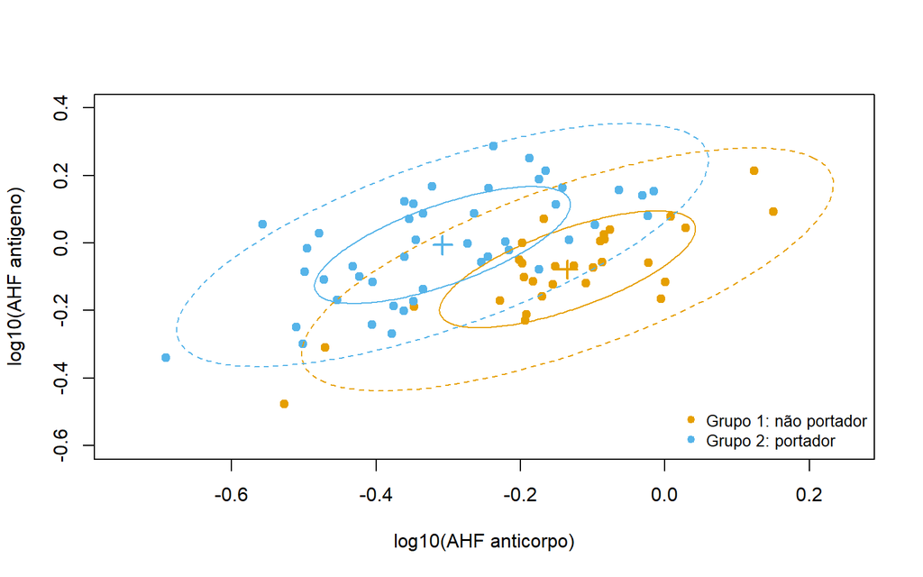

```r
plot(antigeno ~ anticorpo, data = hemofilia, type = "n", xlim = c(-0.75, 0.25), ylim = c(-0.60, 0.40), xlab = "log10(AHF anticorpo)", ylab = "log10(AHF antigeno)")

  # pontos do grupo 1
with(hemofilia, points(anticorpo[grupo==1], antigeno[grupo==1], pch = 21, col= cores[1], bg = cores[1]))
  # pontos do grupo 2
with(hemofilia, points(anticorpo[grupo==2], antigeno[grupo==2], pch = 21, col= cores[2], bg = cores[2]))
  # legenda
legenda <- c("Grupo 1: não portador", "Grupo 2: portador")
legend("bottomright", legend = legenda, pch = c(21, 21), bty = "n",  pt.bg = cores[1:2], col = cores[1:2], cex = 0.85)


    # Elipses de 50% e 95% - Grupo 1
mi <- as.vector(centroide[, 1], mode = "double")
mixtools::ellipse(mu = mi, sigma = S.pool, alpha = 0.05, type = "l",
    lty = 2, npoints = 250, col = cores[1])
mixtools::ellipse(mu = mi, sigma = S.pool, alpha = 0.5,
      npoints = 250, col=cores[1])
points(x = mi[1], y = mi[2], pch = 3, col = cores[1], cex = 1.5, lwd = 2)

    # Elipses de 50% e 95% - Grupo 2
mi <- as.vector(centroide[, 2], mode = "double")
mixtools::ellipse(mu = mi, sigma = S.pool, alpha = 0.05, type = "l",
    lty = 2, npoints = 250, col = cores[2])
mixtools::ellipse(mu = mi, sigma = S.pool, alpha = 0.5,
      npoints = 250, col=cores[2])
points(x = mi[1], y = mi[2], pch = 3, col = cores[2], cex = 1.5, lwd = 2)
```

A normalidade bivariada parece se ajustar bem aos dados.

### Modelos de classificação:

Suponha que o sangue que produz as medidas `log10(AHF anticorpo)` e `log10(AHF antígeno)` seja coletado da prima por parte de mãe de um hemofílico. Então, a chance genética de ser portador de hemofilia A neste caso é de 0,25. Consequentemente, as probabilidades prévias de pertencimento ao grupo são $p_1 = 0.75$ e $p_2 = 0.25$.

**Análise discriminante linear**

Supondo normalidade bivariada, o modelo é obtido por meio do comando `lda()`, do pacote `MASS`.

```r
mod.adL1 <- MASS::lda(grupo ~ anticorpo + antigeno, data = hemofilia, prior = c(0.75, 0.25))
mod.adL1
```

```
## Call:
## lda(grupo ~ anticorpo + antigeno, data = hemofilia, prior = c(0.75,
##     0.25))
##
## Prior probabilities of groups:
##    1    2
## 0.75 0.25
##
## Group means:
##    anticorpo     antigeno
## 1 -0.1348700 -0.077856667
## 2 -0.3079467 -0.005991111
##
## Coefficients of linear discriminants:
##                 LD1
## anticorpo -9.032787
## antigeno   8.006605
```

Os escores discriminantes são determinados pela transformação linear $-9.03\times \mathrm{anticorpo} +8.01\times \mathrm{antigeno}$, em que os coeficientes da combinação linear estão normalizados pela variabilidade entreos dois grupos. O histograma por grupo dos escores discriminantes, estão apresentados na figura abaixo:

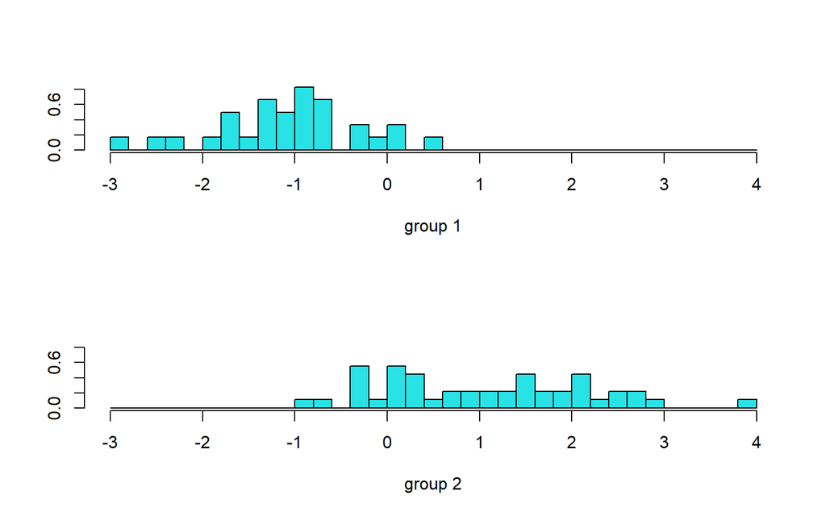

```r
plot(mod.adL1)
```

O modelo linear aparenta ser um desempenho razoável na classificação dos dados (verificação com os mesmos dados utilizados na construção do modelo.). A verificação visual está efetuada abaixo, com o auxílio da função `partimat()`, do pacote `klaR`.

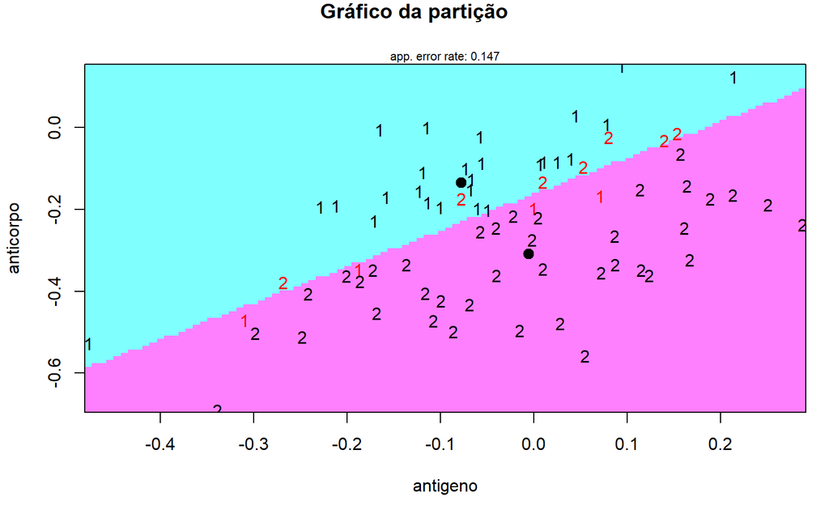

```r
klaR::partimat(grupo ~ ., data = hemofilia, method = "lda",
        main= "Gráfico da partição")
```

**Análise discriminante quadrático**

A Análise Discriminante Quadrática (*QDA*) é um pouco mais flexível do que a linear, no sentido de que não pressupõe a igualdade da estrutura de covariâncias de cada grupo. o discriminante linear tende a ser melhor do que o quadrático o conjunto de treinamento é relativamente pequeno. Em contrapartida, a QDA é recomendada se o conjunto de treinamento for muito grande, de modo que a variância do classificador não seja um problema importante, ou se a suposição mesma matriz de covariâncias para os grupos não for claramente atendida (JAMES et al., 2013). A QDA pode ser calculada usando a função `qda()` [pacote `MASS`].

```r
mod.adQ <- MASS::qda(grupo ~ anticorpo + antigeno, data = hemofilia, prior = c(0.75, 0.25))
mod.adQ
```

```
## Call:
## qda(grupo ~ anticorpo + antigeno, data = hemofilia, prior = c(0.75,
##     0.25))
##
## Prior probabilities of groups:
##    1    2
## 0.75 0.25
##
## Group means:
##    anticorpo     antigeno
## 1 -0.1348700 -0.077856667
## 2 -0.3079467 -0.005991111
```

```r
#plot(mod.adQ)
```

A visualização da aplicação do modelo (no conjunto de treinamento) está apresentada abaixo. Foi utilizada a função `partimat()`, agora modificando o argumento `method = 'qda'`.

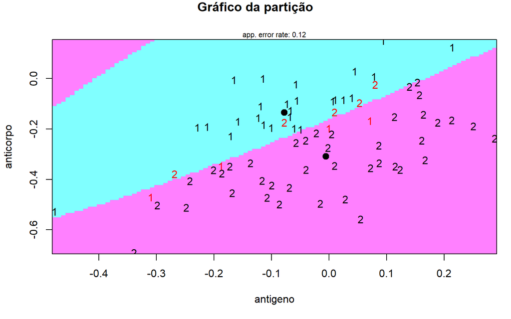

```r
        # Gráfico do pacote klaR
klaR::partimat(grupo ~ ., data = hemofilia, method = "qda",
        main= "Gráfico da partição")
```

O modelo aparenta ter um desempenho semelhante ao obtido pela discriminaçãoi linear. Salienta-se que há evidências amostrais para afirmar que os dois grupos compartilham a estrutura de covariâncias ($\boldsymbol{\Sigma}_1 = \boldsymbol{\Sigma}_2$). Supondo que os grupos tenham normalidade bivariada, foi conduzido o teste de Box para verificação da igualdade das matrizes de covariâncias. Foi utilizada com a função `box_m`, do pacote `rstatix`. Maiores detalhes sobre o teste de homegeneidade de Box podem ser encontrados em JOHNSON; WICHERN (2007, p. 590).

```r
 #Verificação igualdade das matrizes de covariânciaas
rstatix::box_m(data = hemofilia[-1], group = hemofilia$grupo)
```

```
## # A tibble: 1 × 4
##   statistic p.value parameter method
##       <dbl>   <dbl>     <dbl> <chr>
## 1      5.34   0.149         3 Box's M-test for Homogeneity of Covariance Matric…
```

Como o p-valor do teste é 0.149, não há evidências amostrais para rejeitar a hipótese de que $\boldsymbol{\Sigma}_1 = \boldsymbol{\Sigma}_2$ e portanto o modelo de discriminação quadrático não é adequado, levando teoricamente aos mesmos resultados do modelo de discriminação linear.

### Desempenho dos modelos:

Após a construção do modelo de classificação, deve-se determinar sua acurácia (*precisão*) na previção do resultado para novas observações (elemestos amostrais não observados) e que, preferencialmente, não tenham sido utilizadas para construir o modelo. Em outras palavras, queremos estimar o erro de previção. Para tanto, a estratégia básica é: (i) construir o modelo em um conjunto de dados de treinamento; (ii) aplicar o modelo em um novo conjunto de dados de teste para fazer previsões; (iii) calcular os erros de previção. Vamos conhecer resumidamente as principais estratégias para determinar o desempenho do modelo (e os erros de predição). Maiores detalhes sobre o tema pode ser encontrados em KUHN; JOHNSON (2013).

**Método da Ressubstituição**

Como há poucos dados disponíveis, a regra de classificação é usada para classificar os $n = n_1 + n_2$ elementos da amostra conjunta, ou seja, os mesmos elementos participam da estimação da regra de classificação e da estimação dos erros de classificação. A matriz de confusão foi calculado com a função `confusionMatrix`, do pacote `caret`. A adotou-se pertecencer ao grupo `2`, como o evento de interesse (classificação positiva).

```r
predL2 <- predict(mod.adL1)
  # Matriz de confusão - pacote caret
conf2 <- caret::confusionMatrix(data = predL2$class, reference = hemofilia$grupo, positive = "2")
conf2
```

```
## Confusion Matrix and Statistics
##
##           Reference
## Prediction  1  2
##          1 30 18
##          2  0 27
##
##                Accuracy : 0.76
##                  95% CI : (0.6475, 0.8511)
##     No Information Rate : 0.6
##     P-Value [Acc > NIR] : 0.002663
##
##                   Kappa : 0.5455
##
##  Mcnemar's Test P-Value : 6.151e-05
##
##             Sensitivity : 0.600
##             Specificity : 1.000
##          Pos Pred Value : 1.000
##          Neg Pred Value : 0.625
##              Prevalence : 0.600
##          Detection Rate : 0.360
##    Detection Prevalence : 0.360
##       Balanced Accuracy : 0.800
##
##        'Positive' Class : 2
##
```

A acurácia do modelo é **0.76**, com uma taxa de não-informação de 0.6 (maior frequência entre os dois grupos) e índice Kappa de **0.55**. Como medidas de desempenho de interesse ressaltamos: a sensibilidade (**0.6**), a especificidade (**1**) e a acurácia balanceada (**0.8**). Os valores podem ser obtidos individualmente manipulando o objeto `conf2`.

```r
conf2$overall['Accuracy']       # ou conf2$overall[1]
conf2$overall['Kappa']          # ou conf2$overall[2]
conf2$byClass['Sensitivity']    # ou conf2$byClass[1]
conf2$byClass['Specificity']    # ou conf2$byClass[2]
conf2$byClass['Balanced Accuracy'] # ou conf2$byClass[11]
```

```
## Accuracy
##     0.76
##     Kappa
## 0.5454545
## Sensitivity
##         0.6
## Specificity
##           1
## Balanced Accuracy
##               0.8
```

Mesmo com acurácia de 0.76, não sabemos o quão bem o modelo se sairá quando for solicitado a fazer novas previsões para dados que ainda não observados. Esse problema é identificado como *overfitting*, que pode ocorrer quando o modelo tem um desempenho muito bom com dados utilizados para sua construção, que pode ter desempenho bastante diferente com dados não observados (não usados na cosntrução do modelo).

Uma maneira de superar esse problema é não usar todo o conjunto de dados para o treinamento do modelo, podendo remover alguns dados e treinando o modelo com o restante. Depois que o modelo for treinado, os dadps podem ser usados para testar o modelo que foi removido anteriormente. Este é o princípio básico da validação cruzada.

**Holdout**

Nesse método, a amostra conjunta, com ($n = n_1 + n_2$) elementos, é dividida em duas partes, uma que vai servir para a construção do modelo de classificação (*amostra de treinamento*) e outra que será utilizada para estimação das probabilidades de classificações incorretas (*amostra de teste*). A seleção das duas amostra é aleatória. As estimativas das probailidades de classificação incorretas obtidas por esse procedimento não são viciadas.

A desvantagem do método é a redução do tamanho original para estimação da regra de classificação, a qual poderá afetar sua confiabilidade, caso as amostras não sejam grandes. Para que esse método seja eficiente, é recomendável que se deixe “à parte” de 25% a 50% dos elementos da amostra original (JOHNSON; WICHERN, 2007). Para amostras grandes, esse método é melhor que o *método da ressubstituição*. No entanto, ao separar nossos dados em conjuntos de treinamento e teste, corre-se o risco de perder informações vitais que podem estar presentes no conjunto de dados de teste.

**Validação Cruzada K-Fold**

Validação cruzada é uma técnica de avaliação de desempenho para modelos preditivos, que também utiliza parte dos dados disponíveis para ajustar o modelo e outra parte para testá-lo. O procedimento busca evitar *overfitting*, especialmente quando os dados disponíveis são insuficientes. Este método envolve dividir os dados em um número fixo ($K$) de dobras (*folds*) ou partições de tamanhos aproximadamente iguais. A análise é utilizada em cada partição e, em seguida, calcula-se a estimativa do erro médio em todas as partições (*folds*). As escolhas típicas de $K$ estão entre 5 e 10. Quando $K = 5$, o cenário se parece com este:

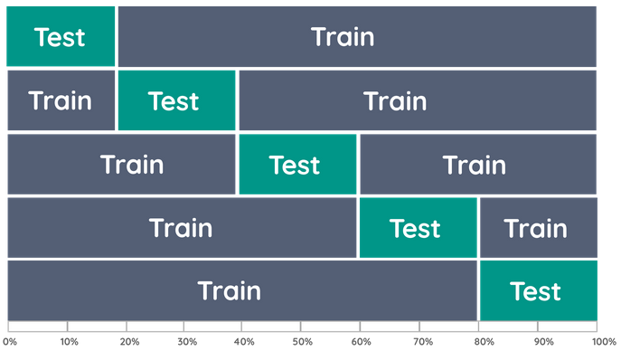

Amostragem *5-Fold*

**Validação Cruzada *Leave-one-out***

Eventualmente, pode não haver dados suficientes para dividir o conjunto de dados em subconjuntos de *treinamento* e de *teste*. Provavelmente, o método mais simples e amplamente utilizado para estimar o erro de predição é a *validação cruzada*. O caso `K = N` é conhecido como validação cruzada leave-one-out. Nesse caso, para a i-ésima observação, o ajuste é calculado usando todos os dados, exceto a i-ésima observação. O procedimento consiste nos seguintes passos:

1. Retira-se um elemento amostral e utilizam-se as demais $n_1 + n_2 -1$ observações amostrais para construir a regra de classificação (em nosso caso, a função discriminante).
2. Utiliza-se a regra de discriminação construída no passo 1) para classificar o elemento amostral que ficou à parte da construção do modelo de classificação, verificando-se se o modelo conseguiu acertar sua reak procedência.
3. Retorna-se à amostra o elemento amostral que foi retirado no passo 1) e escolhe-se uma outra observação. Repetem-se os passos 1) e 2).

O procedimento é repetido até todos os $n_1 + n_2$ elementos amostrais tenham sua classificação predita. As probabilidades de classificação incorreta são então estimadas. As estimativas deste método são aproximadamente não viciadas e melhores que do método da ressubstituição, para populações normais e não-normais (TIMM, 2002).

Observe na figura abaixo que o procedimento de *leave-one-out* é uma validação cruzada *K-Fold*, com $K=n$.

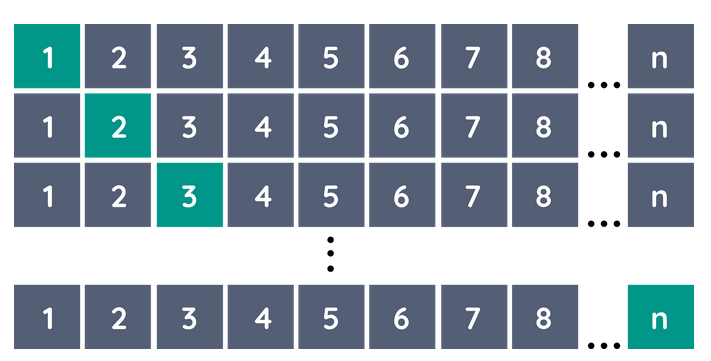

Amostragem *Leave-one-out*

O código a seguir implementa todos passos do procedimento *leave-one-out* para avaliação do modelo de discriminação linear do conjunto de dados `hemofilia.DAT`. Para cada linha `i` do conjunto de dados hemofilia, as classificações *leave-one-out* e a classificação de referência (`hemofilia$grupo`) serão armazenadas no *data frame* `pred.compara`. O erro de cada classificação será armazenado no vetor lógico `erro`

```r
n <- nrow(hemofilia)
  # Inicializacao dos objetos para armazenar valores de RMSE
  # e valor observado e ajustado
erro <- numeric(n)
pred.compara <- data.frame(Observado = numeric(), Predito = numeric())

for (i in 1:n) {
   dados <- hemofilia
   # Exclusão da i-ésima linha
  teste <- dados[i, ]
  treino <- dados[-i, ]

    # Construção do modelo
  modelo <- MASS::lda(grupo ~., data = treino)

    # Predição do dado de teste
  predicao <- predict(modelo, newdata = teste)$class
#print(predicao)
# print(teste$grupo )
  # Calculo do erro
  erro[i] <- (teste$grupo == predicao)

  # Armazena valores Observados vs Preditos
pred.compara <- rbind(pred.compara,
                data.frame(Observado = teste$grupo,
                        Predito = predicao))
}
```

A acurácia estimada pelo método de leave-one-out é calculado pela média do vetor lógico `erro`

```r
mean(erro)
```

```
## [1] 0.8533333
```

A acurácia obtida por este procedimento é 0.85, maior que aquela obtida pelo método da ressubstituição (0.76). O mesmo valor é obtido ao utilizarmos funções do pacote `caret` para realizar o procedimento *leave-one-out*. É importante observar que a variável com os valores de de classificação de referência tem de ser um fator.

```r
            # --- Leave-one-out by caret ----


  # definição controle Leave-one-out
treino_controle <- caret::trainControl(method = "LOOCV",
                        savePredictions = 'final')
  # Treinamento do modelo usando LOOCV
modelo_loo <- caret::train(grupo ~ anticorpo + antigeno, data = hemofilia, method = "lda", trControl = treino_controle)
modelo_loo
```

```
## Linear Discriminant Analysis
##
## 75 samples
##  2 predictor
##  2 classes: '1', '2'
##
## No pre-processing
## Resampling: Leave-One-Out Cross-Validation
## Summary of sample sizes: 74, 74, 74, 74, 74, 74, ...
## Resampling results:
##
##   Accuracy   Kappa
##   0.8533333  0.6994536
```

### Exercício proposto

- Exercício 11.32 (JOHNSON; WICHERN, 2007, p. 663)

### Referências

JAMES, G. et al. **An introduction to statistical learning with applications in R**. New York, NY: Springer, 2013.

JOHNSON, R. A.; WICHERN, D. W. **Applied multivariate statistical analysis**. 6th. ed. Upper Saddle River, NJ: Prentice Hall, 2007.

KUHN, M.; JOHNSON, K. **Applied predictive modeling**. New York, NY: Springer, 2013. v. 26

R CORE TEAM. **[R: A Language and Environment for Statistical Computing](https://www.R-project.org/)**. Vienna, Austria: R Foundation for Statistical Computing, 2025.

TIMM, N. H. **Applied multivariate analysis**. New York, NY: Springer, 2002.